# Lab01.2

# Os politicos que mais tuitam são os que possuem um maior engajamento próprio? Isso interefe de alguma forma no total de engajamento?

Como demonstrado na visualização, os 5 políticos que mais tuitam são: Bacelar, Margarida Salomão, Marcelo Freixo, Alvaro Dias e Humberto Costa. Já os políticos que tem um maior engajamento proprio são: Carla zambelli, Joice Hasselmann, Marcelo Freixo, Talíria Petrone e David Miranda. Podemos perceber que a quantidade de tweets não interfere quando determinamos um nivel de engajamento proprio, visto que apenas Marcelo Freixo tuita bastante e tem um alto engajamento próprio.

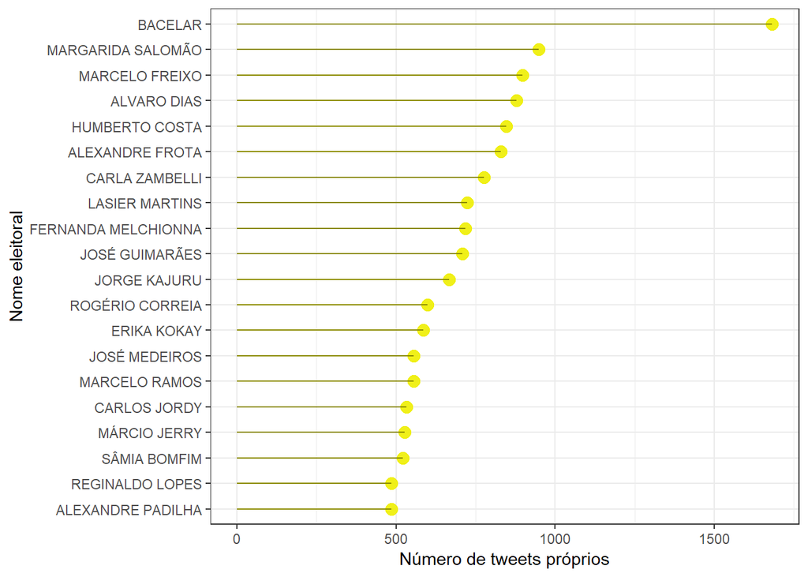

```r
atividade %>%
  na.omit(.) %>%
  group_by(nome_eleitoral) %>%
  summarise(soma = sum(n_proprio)) %>%
  arrange(-soma) %>%
  slice(1:20) %>%
  ggplot(aes(x = reorder(nome_eleitoral,
                         as.double(soma)),
             y =soma)) +
  geom_point(size=3.3,
             color = "yellow2",
             alpha= 0.9)+
  geom_segment(aes(x= nome_eleitoral,
                   xend= nome_eleitoral,
                   y= 0,
                   yend=soma),
               color= "yellow4")+
  coord_flip()+
  labs(x = "Nome eleitoral", y="Número de tweets próprios")
```

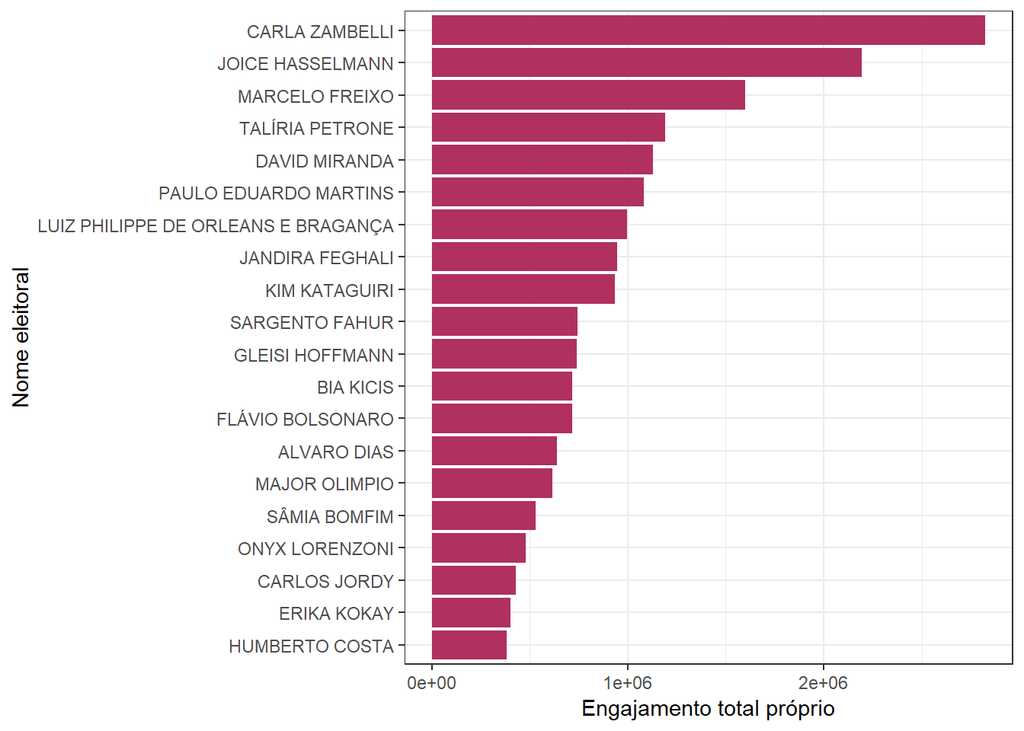

```r
atividade %>%
  na.omit(.) %>%
  group_by(nome_eleitoral) %>%
  summarise(soma = sum(engaj_total_proprio)) %>%
  arrange(-soma) %>%
  slice(1:20) %>%
  ggplot(aes(x = reorder(nome_eleitoral, as.double(soma)), y = soma)) +
  geom_col(fill="maroon")+ coord_flip()+ labs(x = "Nome eleitoral", y="Engajamento total próprio")
```

# Os estados dos politicos com maior engajamento próprio são os estados com a maior quantidade de politicos? A quantidade de politicos por estado influencia essa medida?

Seis dos estados com um engajamento proprio alto são: SP, RJ, PR, RS, DF e MG. Já os estados com maior quantidade de politicos em ordem decrescente são: SP, MG, RJ, RS, PR e BA. Conseguimos observar que os estados foram comuns em sua maioria, divergindo apenas pelo estado da Bahia, que não aparece entre os primeiros 6 com maior engajamento. Isso nos mostra que a quantidade de políticos no estado influencia o nivel de engajamento, mas não determina com precisão a posição do estado no ranking.

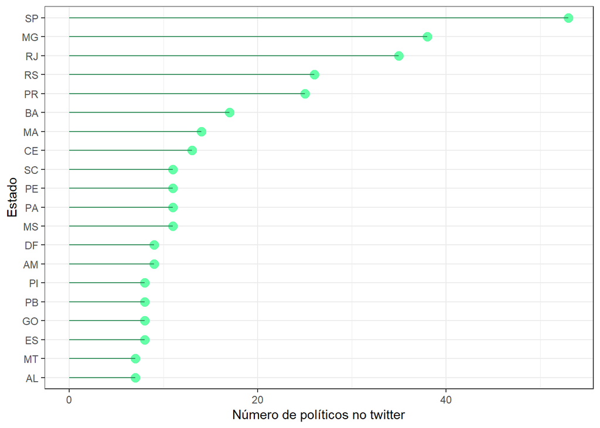

```r
atividade %>%
  na.omit(.) %>%
  group_by(UF) %>%
  summarise(soma = n()) %>%
  arrange(-soma) %>%
  slice(1:20) %>%
  ggplot(aes(x = reorder(UF, as.double(soma)),
             y = soma)) +
  geom_point(size=3.3,
             color = "seagreen1",
             alpha= 0.9)+
  geom_segment(aes(x =UF,
                   xend= UF,
                   y= 0,
                   yend= soma),
                   color= "seagreen")+
  coord_flip()+
  labs(x = "Estado", y="Número de políticos no twitter")
```

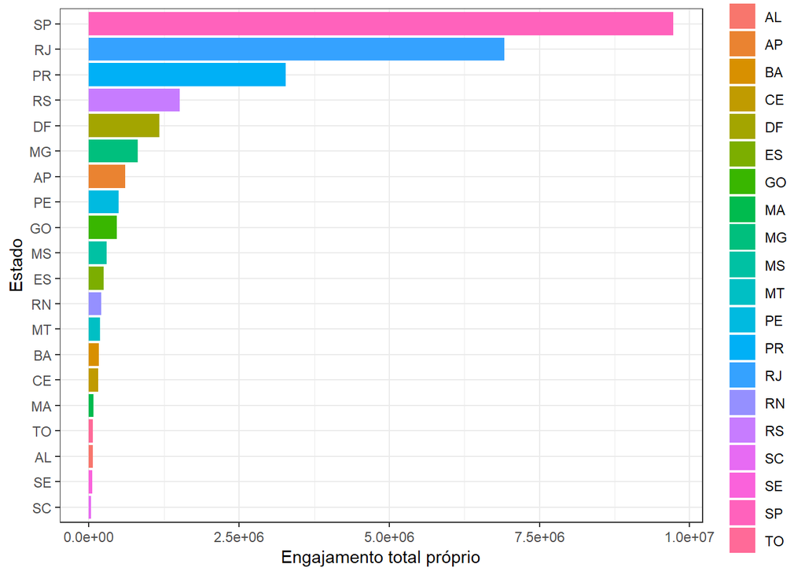

```r
atividade %>%
  na.omit(.) %>%
  group_by(UF) %>%
  summarise(soma = sum(engaj_total_proprio)) %>%
  arrange(-soma) %>%
  slice(1:20) %>%
  ggplot(aes(x = reorder(UF,
                         as.double(soma)),
             y = soma, fill = UF)) +
  geom_col()+
  coord_flip()+
  labs(x = "Estado", y="Engajamento total próprio")
```